# Risk Factor Analysis

## Outcome Variable

**Outcome Variable:** stunted

## Predictor Variables

**Intervention Variable:** exclfeed36

**Adjustment Set:**

- arm
- sex
- W_mage
- meducyrs
- feducyrs
- hhwealth_quart
- hfoodsec
- W_mhtcm
- vagbrth
- W_gagebrth
- W_birthwt
- W_birthlen
- W_nrooms
- W_nchldlt5
- month
- brthmon
- W_parity
- impfloor
- impsan
- safeh20
- delta_W_mage
- delta_meducyrs
- delta_feducyrs
- delta_hhwealth_quart
- delta_hfoodsec
- delta_W_mhtcm
- delta_vagbrth
- delta_W_gagebrth
- delta_W_birthwt
- delta_W_birthlen
- delta_W_nrooms
- delta_W_nchldlt5
- delta_month
- delta_brthmon
- delta_W_parity
- delta_impfloor
- delta_impsan
- delta_safeh20

## Stratifying Variables

The analysis was stratified on these variable(s):

- agecat
- studyid
- country

## Data Summary

| agecat | studyid | country | exclfeed36 | stunted | n_cell | n |
| --- | --- | --- | --- | --- | --- | --- |
| Birth | ki0047075b-MAL-ED | BANGLADESH | 1 | 0 | 51 | 243 |
| Birth | ki0047075b-MAL-ED | BANGLADESH | 1 | 1 | 11 | 243 |
| Birth | ki0047075b-MAL-ED | BANGLADESH | 0 | 0 | 151 | 243 |
| Birth | ki0047075b-MAL-ED | BANGLADESH | 0 | 1 | 30 | 243 |
| Birth | ki0047075b-MAL-ED | BRAZIL | 1 | 0 | 10 | 185 |
| Birth | ki0047075b-MAL-ED | BRAZIL | 1 | 1 | 3 | 185 |
| Birth | ki0047075b-MAL-ED | BRAZIL | 0 | 0 | 156 | 185 |
| Birth | ki0047075b-MAL-ED | BRAZIL | 0 | 1 | 16 | 185 |
| Birth | ki0047075b-MAL-ED | INDIA | 1 | 0 | 2 | 198 |
| Birth | ki0047075b-MAL-ED | INDIA | 1 | 1 | 3 | 198 |
| Birth | ki0047075b-MAL-ED | INDIA | 0 | 0 | 164 | 198 |
| Birth | ki0047075b-MAL-ED | INDIA | 0 | 1 | 29 | 198 |
| Birth | ki0047075b-MAL-ED | NEPAL | 1 | 0 | 11 | 172 |
| Birth | ki0047075b-MAL-ED | NEPAL | 1 | 1 | 0 | 172 |
| Birth | ki0047075b-MAL-ED | NEPAL | 0 | 0 | 143 | 172 |
| Birth | ki0047075b-MAL-ED | NEPAL | 0 | 1 | 18 | 172 |
| Birth | ki0047075b-MAL-ED | PERU | 1 | 0 | 13 | 273 |
| Birth | ki0047075b-MAL-ED | PERU | 1 | 1 | 2 | 273 |
| Birth | ki0047075b-MAL-ED | PERU | 0 | 0 | 228 | 273 |
| Birth | ki0047075b-MAL-ED | PERU | 0 | 1 | 30 | 273 |
| Birth | ki0047075b-MAL-ED | SOUTH AFRICA | 1 | 0 | 0 | 236 |
| Birth | ki0047075b-MAL-ED | SOUTH AFRICA | 1 | 1 | 0 | 236 |
| Birth | ki0047075b-MAL-ED | SOUTH AFRICA | 0 | 0 | 212 | 236 |
| Birth | ki0047075b-MAL-ED | SOUTH AFRICA | 0 | 1 | 24 | 236 |
| Birth | ki0047075b-MAL-ED | TANZANIA, UNITED REPUBLIC OF | 1 | 0 | 1 | 121 |
| Birth | ki0047075b-MAL-ED | TANZANIA, UNITED REPUBLIC OF | 1 | 1 | 0 | 121 |
| Birth | ki0047075b-MAL-ED | TANZANIA, UNITED REPUBLIC OF | 0 | 0 | 102 | 121 |
| Birth | ki0047075b-MAL-ED | TANZANIA, UNITED REPUBLIC OF | 0 | 1 | 18 | 121 |
| Birth | ki1000108-CMC-V-BCS-2002 | INDIA | 1 | 0 | 3 | 3 |
| Birth | ki1000108-CMC-V-BCS-2002 | INDIA | 1 | 1 | 0 | 3 |

[output cut: 150 more lines]

The following strata were considered:

- agecat: 24 months, studyid: ki0047075b-MAL-ED, country: BANGLADESH
- agecat: 24 months, studyid: ki0047075b-MAL-ED, country: BRAZIL
- agecat: 24 months, studyid: ki0047075b-MAL-ED, country: INDIA
- agecat: 24 months, studyid: ki0047075b-MAL-ED, country: NEPAL
- agecat: 24 months, studyid: ki0047075b-MAL-ED, country: PERU
- agecat: 24 months, studyid: ki0047075b-MAL-ED, country: SOUTH AFRICA
- agecat: 24 months, studyid: ki0047075b-MAL-ED, country: TANZANIA, UNITED REPUBLIC OF
- agecat: 24 months, studyid: ki1000108-CMC-V-BCS-2002, country: INDIA
- agecat: 24 months, studyid: ki1000108-IRC, country: INDIA
- agecat: 24 months, studyid: ki1017093b-PROVIDE, country: BANGLADESH
- agecat: 24 months, studyid: ki1101329-Keneba, country: GAMBIA
- agecat: 24 months, studyid: ki1113344-GMS-Nepal, country: NEPAL
- agecat: 24 months, studyid: ki1148112-LCNI-5, country: MALAWI
- agecat: 24 months, studyid: kiGH5241-JiVitA-3, country: BANGLADESH
- agecat: 24 months, studyid: kiGH5241-JiVitA-4, country: BANGLADESH
- agecat: 6 months, studyid: ki0047075b-MAL-ED, country: BANGLADESH
- agecat: 6 months, studyid: ki0047075b-MAL-ED, country: BRAZIL
- agecat: 6 months, studyid: ki0047075b-MAL-ED, country: INDIA
- agecat: 6 months, studyid: ki0047075b-MAL-ED, country: NEPAL
- agecat: 6 months, studyid: ki0047075b-MAL-ED, country: PERU
- agecat: 6 months, studyid: ki0047075b-MAL-ED, country: SOUTH AFRICA
- agecat: 6 months, studyid: ki0047075b-MAL-ED, country: TANZANIA, UNITED REPUBLIC OF
- agecat: 6 months, studyid: ki1000108-CMC-V-BCS-2002, country: INDIA
- agecat: 6 months, studyid: ki1000108-IRC, country: INDIA
- agecat: 6 months, studyid: ki1000109-EE, country: PAKISTAN
- agecat: 6 months, studyid: ki1000304b-SAS-FoodSuppl, country: INDIA
- agecat: 6 months, studyid: ki1017093b-PROVIDE, country: BANGLADESH
- agecat: 6 months, studyid: ki1101329-Keneba, country: GAMBIA
- agecat: 6 months, studyid: ki1113344-GMS-Nepal, country: NEPAL
- agecat: 6 months, studyid: ki1148112-LCNI-5, country: MALAWI
- agecat: 6 months, studyid: kiGH5241-JiVitA-3, country: BANGLADESH
- agecat: 6 months, studyid: kiGH5241-JiVitA-4, country: BANGLADESH
- agecat: Birth, studyid: ki0047075b-MAL-ED, country: BANGLADESH
- agecat: Birth, studyid: ki0047075b-MAL-ED, country: BRAZIL
- agecat: Birth, studyid: ki0047075b-MAL-ED, country: INDIA
- agecat: Birth, studyid: ki0047075b-MAL-ED, country: NEPAL
- agecat: Birth, studyid: ki0047075b-MAL-ED, country: PERU
- agecat: Birth, studyid: ki0047075b-MAL-ED, country: SOUTH AFRICA
- agecat: Birth, studyid: ki0047075b-MAL-ED, country: TANZANIA, UNITED REPUBLIC OF
- agecat: Birth, studyid: ki1000108-CMC-V-BCS-2002, country: INDIA
- agecat: Birth, studyid: ki1000108-IRC, country: INDIA
- agecat: Birth, studyid: ki1000109-EE, country: PAKISTAN
- agecat: Birth, studyid: ki1101329-Keneba, country: GAMBIA
- agecat: Birth, studyid: kiGH5241-JiVitA-3, country: BANGLADESH
- agecat: Birth, studyid: kiGH5241-JiVitA-4, country: BANGLADESH

### Dropped Strata

Some strata were dropped due to rare outcomes:

- agecat: Birth, studyid: ki0047075b-MAL-ED, country: BRAZIL
- agecat: Birth, studyid: ki0047075b-MAL-ED, country: INDIA
- agecat: Birth, studyid: ki0047075b-MAL-ED, country: NEPAL
- agecat: Birth, studyid: ki0047075b-MAL-ED, country: PERU
- agecat: Birth, studyid: ki0047075b-MAL-ED, country: SOUTH AFRICA
- agecat: Birth, studyid: ki0047075b-MAL-ED, country: TANZANIA, UNITED REPUBLIC OF
- agecat: Birth, studyid: ki1000108-CMC-V-BCS-2002, country: INDIA
- agecat: Birth, studyid: ki1000108-IRC, country: INDIA
- agecat: Birth, studyid: ki1000109-EE, country: PAKISTAN
- agecat: 6 months, studyid: ki0047075b-MAL-ED, country: BRAZIL
- agecat: 6 months, studyid: ki0047075b-MAL-ED, country: INDIA
- agecat: 6 months, studyid: ki0047075b-MAL-ED, country: NEPAL
- agecat: 6 months, studyid: ki0047075b-MAL-ED, country: PERU
- agecat: 6 months, studyid: ki0047075b-MAL-ED, country: SOUTH AFRICA
- agecat: 6 months, studyid: ki0047075b-MAL-ED, country: TANZANIA, UNITED REPUBLIC OF
- agecat: 6 months, studyid: ki1000108-CMC-V-BCS-2002, country: INDIA
- agecat: 6 months, studyid: ki1000108-IRC, country: INDIA
- agecat: 6 months, studyid: ki1000304b-SAS-FoodSuppl, country: INDIA
- agecat: 24 months, studyid: ki0047075b-MAL-ED, country: BRAZIL
- agecat: 24 months, studyid: ki0047075b-MAL-ED, country: INDIA
- agecat: 24 months, studyid: ki0047075b-MAL-ED, country: NEPAL
- agecat: 24 months, studyid: ki0047075b-MAL-ED, country: SOUTH AFRICA
- agecat: 24 months, studyid: ki0047075b-MAL-ED, country: TANZANIA, UNITED REPUBLIC OF
- agecat: 24 months, studyid: ki1000108-CMC-V-BCS-2002, country: INDIA
- agecat: 24 months, studyid: ki1000108-IRC, country: INDIA

## Methods Detail

We’re interested in the causal parameters $E[Y_a]$ for all values of $a \in \mathcal{A}$. These parameters represent the mean outcome if, possibly contrary to fact, we intervened to set all units to have $A=a$. Under the randomization and positivity assumptions, these are identified by the statistical parameters $\psi_a=E_W[E_{Y|A,W}(Y|A=a,W)]$. In addition, we’re interested in the mean of $Y$, $E[Y]$ under no intervention (the observed mean). We will estimate these parameters by using SuperLearner to fit the relevant likelihood factors – $E_{Y|A,W}(Y|A=a,W)$ and $p(A=a|W)$, and then updating our likelihood fit using a joint TMLE.

For unadjusted analyses ($W=\{\}$), initial likelihoods were estimated using Lrnr_glm to estimate the simple $E(Y|A)$ and Lrnr_mean to estimate $p(A)$. For adjusted analyses, a small library containing Lrnr_glmnet, Lrnr_xgboost, and Lrnr_mean was used.

Having estimated these parameters, we will then use the delta method to estimate relative risks and attributable risks relative to a prespecified baseline level of $A$.

# Results Detail

## Results Plots

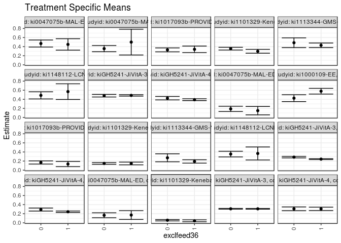

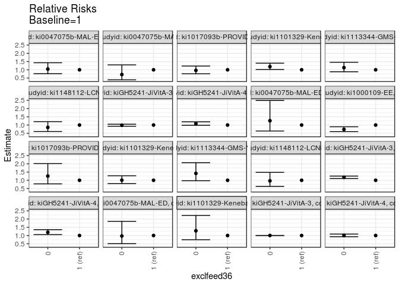

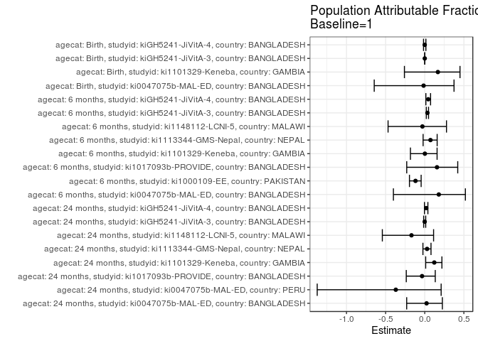

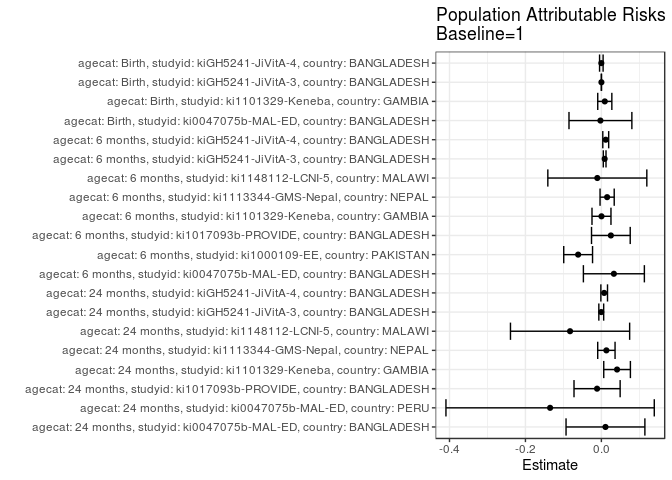

## Results Table

### Parameter: TSM

| agecat | studyid | country | intervention_level | baseline_level | estimate | ci_lower | ci_upper |
| --- | --- | --- | --- | --- | --- | --- | --- |
| Birth | ki0047075b-MAL-ED | BANGLADESH | 1 | NA | 0.1712156 | 0.0747054 | 0.2677258 |
| Birth | ki0047075b-MAL-ED | BANGLADESH | 0 | NA | 0.1660455 | 0.1117375 | 0.2203534 |
| Birth | ki1101329-Keneba | GAMBIA | 1 | NA | 0.0445267 | 0.0233039 | 0.0657495 |
| Birth | ki1101329-Keneba | GAMBIA | 0 | NA | 0.0572228 | 0.0419530 | 0.0724927 |
| Birth | kiGH5241-JiVitA-3 | BANGLADESH | 1 | NA | 0.3082771 | 0.2996053 | 0.3169489 |
| Birth | kiGH5241-JiVitA-3 | BANGLADESH | 0 | NA | 0.3087909 | 0.3001186 | 0.3174632 |
| Birth | kiGH5241-JiVitA-4 | BANGLADESH | 1 | NA | 0.3068376 | 0.2690939 | 0.3445813 |
| Birth | kiGH5241-JiVitA-4 | BANGLADESH | 0 | NA | 0.3080907 | 0.2662248 | 0.3499566 |
| 6 months | ki0047075b-MAL-ED | BANGLADESH | 1 | NA | 0.1503994 | 0.0579549 | 0.2428439 |
| 6 months | ki0047075b-MAL-ED | BANGLADESH | 0 | NA | 0.1895423 | 0.1320369 | 0.2470477 |
| 6 months | ki1000109-EE | PAKISTAN | 1 | NA | 0.5789121 | 0.5161642 | 0.6416601 |
| 6 months | ki1000109-EE | PAKISTAN | 0 | NA | 0.4252762 | 0.3498918 | 0.5006606 |
| 6 months | ki1017093b-PROVIDE | BANGLADESH | 1 | NA | 0.1347859 | 0.0774554 | 0.1921165 |
| 6 months | ki1017093b-PROVIDE | BANGLADESH | 0 | NA | 0.1693301 | 0.1344951 | 0.2041652 |
| 6 months | ki1101329-Keneba | GAMBIA | 1 | NA | 0.1472114 | 0.1173290 | 0.1770938 |
| 6 months | ki1101329-Keneba | GAMBIA | 0 | NA | 0.1482494 | 0.1290737 | 0.1674252 |
| 6 months | ki1113344-GMS-Nepal | NEPAL | 1 | NA | 0.1920644 | 0.1544359 | 0.2296929 |
| 6 months | ki1113344-GMS-Nepal | NEPAL | 0 | NA | 0.2721557 | 0.1843699 | 0.3599415 |
| 6 months | ki1148112-LCNI-5 | MALAWI | 1 | NA | 0.3672813 | 0.2244385 | 0.5101241 |
| 6 months | ki1148112-LCNI-5 | MALAWI | 0 | NA | 0.3541404 | 0.2914150 | 0.4168658 |
| 6 months | kiGH5241-JiVitA-3 | BANGLADESH | 1 | NA | 0.2428170 | 0.2335871 | 0.2520468 |
| 6 months | kiGH5241-JiVitA-3 | BANGLADESH | 0 | NA | 0.2864698 | 0.2698541 | 0.3030856 |
| 6 months | kiGH5241-JiVitA-4 | BANGLADESH | 1 | NA | 0.2443337 | 0.2281871 | 0.2604803 |
| 6 months | kiGH5241-JiVitA-4 | BANGLADESH | 0 | NA | 0.2924909 | 0.2593417 | 0.3256401 |
| 24 months | ki0047075b-MAL-ED | BANGLADESH | 1 | NA | 0.4489463 | 0.3233964 | 0.5744961 |
| 24 months | ki0047075b-MAL-ED | BANGLADESH | 0 | NA | 0.4688794 | 0.3913078 | 0.5464509 |
| 24 months | ki0047075b-MAL-ED | PERU | 1 | NA | 0.5000000 | 0.2163937 | 0.7836063 |
| 24 months | ki0047075b-MAL-ED | PERU | 0 | NA | 0.3563830 | 0.2877505 | 0.4250155 |
| 24 months | ki1017093b-PROVIDE | BANGLADESH | 1 | NA | 0.3411906 | 0.2689907 | 0.4133905 |
| 24 months | ki1017093b-PROVIDE | BANGLADESH | 0 | NA | 0.3288130 | 0.2851524 | 0.3724735 |
| 24 months | ki1101329-Keneba | GAMBIA | 1 | NA | 0.2979805 | 0.2559679 | 0.3399931 |
| 24 months | ki1101329-Keneba | GAMBIA | 0 | NA | 0.3557978 | 0.3261134 | 0.3854823 |
| 24 months | ki1113344-GMS-Nepal | NEPAL | 1 | NA | 0.4297924 | 0.3792851 | 0.4802997 |
| 24 months | ki1113344-GMS-Nepal | NEPAL | 0 | NA | 0.4860582 | 0.3784382 | 0.5936782 |
| 24 months | ki1148112-LCNI-5 | MALAWI | 1 | NA | 0.5692521 | 0.3968203 | 0.7416840 |
| 24 months | ki1148112-LCNI-5 | MALAWI | 0 | NA | 0.4867905 | 0.4081120 | 0.5654690 |
| 24 months | kiGH5241-JiVitA-3 | BANGLADESH | 1 | NA | 0.4860461 | 0.4705623 | 0.5015300 |
| 24 months | kiGH5241-JiVitA-3 | BANGLADESH | 0 | NA | 0.4797200 | 0.4512672 | 0.5081728 |
| 24 months | kiGH5241-JiVitA-4 | BANGLADESH | 1 | NA | 0.3917961 | 0.3715614 | 0.4120307 |
| 24 months | kiGH5241-JiVitA-4 | BANGLADESH | 0 | NA | 0.4250399 | 0.3868590 | 0.4632208 |

### Parameter: E(Y)

| agecat | studyid | country | intervention_level | baseline_level | estimate | ci_lower | ci_upper |
| --- | --- | --- | --- | --- | --- | --- | --- |
| Birth | ki0047075b-MAL-ED | BANGLADESH | NA | NA | 0.1687243 | 0.1215395 | 0.2159090 |
| Birth | ki1101329-Keneba | GAMBIA | NA | NA | 0.0535144 | 0.0410431 | 0.0659857 |
| Birth | kiGH5241-JiVitA-3 | BANGLADESH | NA | NA | 0.3084038 | 0.2997331 | 0.3170746 |
| Birth | kiGH5241-JiVitA-4 | BANGLADESH | NA | NA | 0.3067400 | 0.2694794 | 0.3440006 |
| 6 months | ki0047075b-MAL-ED | BANGLADESH | NA | NA | 0.1833333 | 0.1342773 | 0.2323893 |
| 6 months | ki1000109-EE | PAKISTAN | NA | NA | 0.5177112 | 0.4665188 | 0.5689035 |
| 6 months | ki1017093b-PROVIDE | BANGLADESH | NA | NA | 0.1597938 | 0.1299995 | 0.1895881 |
| 6 months | ki1101329-Keneba | GAMBIA | NA | NA | 0.1474860 | 0.1310548 | 0.1639172 |
| 6 months | ki1113344-GMS-Nepal | NEPAL | NA | NA | 0.2072243 | 0.1725535 | 0.2418951 |
| 6 months | ki1148112-LCNI-5 | MALAWI | NA | NA | 0.3566176 | 0.2995882 | 0.4136471 |
| 6 months | kiGH5241-JiVitA-3 | BANGLADESH | NA | NA | 0.2514393 | 0.2427410 | 0.2601375 |
| 6 months | kiGH5241-JiVitA-4 | BANGLADESH | NA | NA | 0.2558140 | 0.2405969 | 0.2710310 |
| 24 months | ki0047075b-MAL-ED | BANGLADESH | NA | NA | 0.4597156 | 0.3923103 | 0.5271210 |
| 24 months | ki0047075b-MAL-ED | PERU | NA | NA | 0.3650000 | 0.2981110 | 0.4318890 |
| 24 months | ki1017093b-PROVIDE | BANGLADESH | NA | NA | 0.3298611 | 0.2914318 | 0.3682904 |
| 24 months | ki1101329-Keneba | GAMBIA | NA | NA | 0.3393113 | 0.3144474 | 0.3641753 |
| 24 months | ki1113344-GMS-Nepal | NEPAL | NA | NA | 0.4429825 | 0.3973399 | 0.4886250 |
| 24 months | ki1148112-LCNI-5 | MALAWI | NA | NA | 0.4867725 | 0.4153250 | 0.5582200 |
| 24 months | kiGH5241-JiVitA-3 | BANGLADESH | NA | NA | 0.4857314 | 0.4714029 | 0.5000599 |
| 24 months | kiGH5241-JiVitA-4 | BANGLADESH | NA | NA | 0.3992046 | 0.3802350 | 0.4181742 |

### Parameter: RR

| agecat | studyid | country | intervention_level | baseline_level | estimate | ci_lower | ci_upper |
| --- | --- | --- | --- | --- | --- | --- | --- |
| Birth | ki0047075b-MAL-ED | BANGLADESH | 1 | 1 | 1.0000000 | 1.0000000 | 1.0000000 |
| Birth | ki0047075b-MAL-ED | BANGLADESH | 0 | 1 | 0.9698033 | 0.5054336 | 1.8608152 |
| Birth | ki1101329-Keneba | GAMBIA | 1 | 1 | 1.0000000 | 1.0000000 | 1.0000000 |
| Birth | ki1101329-Keneba | GAMBIA | 0 | 1 | 1.2851354 | 0.7443691 | 2.2187554 |
| Birth | kiGH5241-JiVitA-3 | BANGLADESH | 1 | 1 | 1.0000000 | 1.0000000 | 1.0000000 |
| Birth | kiGH5241-JiVitA-3 | BANGLADESH | 0 | 1 | 1.0016667 | 1.0005046 | 1.0028301 |
| Birth | kiGH5241-JiVitA-4 | BANGLADESH | 1 | 1 | 1.0000000 | 1.0000000 | 1.0000000 |
| Birth | kiGH5241-JiVitA-4 | BANGLADESH | 0 | 1 | 1.0040838 | 0.9264713 | 1.0881981 |
| 6 months | ki0047075b-MAL-ED | BANGLADESH | 1 | 1 | 1.0000000 | 1.0000000 | 1.0000000 |
| 6 months | ki0047075b-MAL-ED | BANGLADESH | 0 | 1 | 1.2602593 | 0.6381718 | 2.4887555 |
| 6 months | ki1000109-EE | PAKISTAN | 1 | 1 | 1.0000000 | 1.0000000 | 1.0000000 |
| 6 months | ki1000109-EE | PAKISTAN | 0 | 1 | 0.7346127 | 0.6028777 | 0.8951331 |
| 6 months | ki1017093b-PROVIDE | BANGLADESH | 1 | 1 | 1.0000000 | 1.0000000 | 1.0000000 |
| 6 months | ki1017093b-PROVIDE | BANGLADESH | 0 | 1 | 1.2562892 | 0.7838178 | 2.0135580 |
| 6 months | ki1101329-Keneba | GAMBIA | 1 | 1 | 1.0000000 | 1.0000000 | 1.0000000 |
| 6 months | ki1101329-Keneba | GAMBIA | 0 | 1 | 1.0070514 | 0.7959465 | 1.2741468 |
| 6 months | ki1113344-GMS-Nepal | NEPAL | 1 | 1 | 1.0000000 | 1.0000000 | 1.0000000 |
| 6 months | ki1113344-GMS-Nepal | NEPAL | 0 | 1 | 1.4170023 | 0.9714660 | 2.0668714 |
| 6 months | ki1148112-LCNI-5 | MALAWI | 1 | 1 | 1.0000000 | 1.0000000 | 1.0000000 |
| 6 months | ki1148112-LCNI-5 | MALAWI | 0 | 1 | 0.9642212 | 0.6283829 | 1.4795478 |
| 6 months | kiGH5241-JiVitA-3 | BANGLADESH | 1 | 1 | 1.0000000 | 1.0000000 | 1.0000000 |
| 6 months | kiGH5241-JiVitA-3 | BANGLADESH | 0 | 1 | 1.1797768 | 1.1086481 | 1.2554690 |
| 6 months | kiGH5241-JiVitA-4 | BANGLADESH | 1 | 1 | 1.0000000 | 1.0000000 | 1.0000000 |
| 6 months | kiGH5241-JiVitA-4 | BANGLADESH | 0 | 1 | 1.1970961 | 1.0571710 | 1.3555414 |
| 24 months | ki0047075b-MAL-ED | BANGLADESH | 1 | 1 | 1.0000000 | 1.0000000 | 1.0000000 |
| 24 months | ki0047075b-MAL-ED | BANGLADESH | 0 | 1 | 1.0443997 | 0.7630076 | 1.4295672 |
| 24 months | ki0047075b-MAL-ED | PERU | 1 | 1 | 1.0000000 | 1.0000000 | 1.0000000 |
| 24 months | ki0047075b-MAL-ED | PERU | 0 | 1 | 0.7127660 | 0.3915602 | 1.2974641 |
| 24 months | ki1017093b-PROVIDE | BANGLADESH | 1 | 1 | 1.0000000 | 1.0000000 | 1.0000000 |
| 24 months | ki1017093b-PROVIDE | BANGLADESH | 0 | 1 | 0.9637222 | 0.7563293 | 1.2279843 |
| 24 months | ki1101329-Keneba | GAMBIA | 1 | 1 | 1.0000000 | 1.0000000 | 1.0000000 |
| 24 months | ki1101329-Keneba | GAMBIA | 0 | 1 | 1.1940305 | 1.0169704 | 1.4019178 |
| 24 months | ki1113344-GMS-Nepal | NEPAL | 1 | 1 | 1.0000000 | 1.0000000 | 1.0000000 |
| 24 months | ki1113344-GMS-Nepal | NEPAL | 0 | 1 | 1.1309138 | 0.8802735 | 1.4529190 |
| 24 months | ki1148112-LCNI-5 | MALAWI | 1 | 1 | 1.0000000 | 1.0000000 | 1.0000000 |
| 24 months | ki1148112-LCNI-5 | MALAWI | 0 | 1 | 0.8551404 | 0.6070697 | 1.2045818 |
| 24 months | kiGH5241-JiVitA-3 | BANGLADESH | 1 | 1 | 1.0000000 | 1.0000000 | 1.0000000 |
| 24 months | kiGH5241-JiVitA-3 | BANGLADESH | 0 | 1 | 0.9869845 | 0.9267815 | 1.0510983 |
| 24 months | kiGH5241-JiVitA-4 | BANGLADESH | 1 | 1 | 1.0000000 | 1.0000000 | 1.0000000 |
| 24 months | kiGH5241-JiVitA-4 | BANGLADESH | 0 | 1 | 1.0848498 | 0.9854060 | 1.1943291 |

### Parameter: PAR

| agecat | studyid | country | intervention_level | baseline_level | estimate | ci_lower | ci_upper |
| --- | --- | --- | --- | --- | --- | --- | --- |
| Birth | ki0047075b-MAL-ED | BANGLADESH | 1 | NA | -0.0024913 | -0.0852794 | 0.0802968 |
| Birth | ki1101329-Keneba | GAMBIA | 1 | NA | 0.0089877 | -0.0095889 | 0.0275643 |
| Birth | kiGH5241-JiVitA-3 | BANGLADESH | 1 | NA | 0.0001267 | 0.0000462 | 0.0002073 |
| Birth | kiGH5241-JiVitA-4 | BANGLADESH | 1 | NA | -0.0000976 | -0.0047523 | 0.0045571 |
| 6 months | ki0047075b-MAL-ED | BANGLADESH | 1 | NA | 0.0329339 | -0.0473633 | 0.1132311 |
| 6 months | ki1000109-EE | PAKISTAN | 1 | NA | -0.0612010 | -0.0991511 | -0.0232508 |
| 6 months | ki1017093b-PROVIDE | BANGLADESH | 1 | NA | 0.0250079 | -0.0259495 | 0.0759653 |
| 6 months | ki1101329-Keneba | GAMBIA | 1 | NA | 0.0002746 | -0.0247133 | 0.0252626 |
| 6 months | ki1113344-GMS-Nepal | NEPAL | 1 | NA | 0.0151599 | -0.0034988 | 0.0338187 |
| 6 months | ki1148112-LCNI-5 | MALAWI | 1 | NA | -0.0106636 | -0.1410151 | 0.1196878 |
| 6 months | kiGH5241-JiVitA-3 | BANGLADESH | 1 | NA | 0.0086223 | 0.0050422 | 0.0122024 |
| 6 months | kiGH5241-JiVitA-4 | BANGLADESH | 1 | NA | 0.0114803 | 0.0037311 | 0.0192295 |
| 24 months | ki0047075b-MAL-ED | BANGLADESH | 1 | NA | 0.0107694 | -0.0930461 | 0.1145848 |
| 24 months | ki0047075b-MAL-ED | PERU | 1 | NA | -0.1350000 | -0.4093261 | 0.1393261 |
| 24 months | ki1017093b-PROVIDE | BANGLADESH | 1 | NA | -0.0113295 | -0.0720687 | 0.0494097 |
| 24 months | ki1101329-Keneba | GAMBIA | 1 | NA | 0.0413308 | 0.0062285 | 0.0764331 |
| 24 months | ki1113344-GMS-Nepal | NEPAL | 1 | NA | 0.0131900 | -0.0096453 | 0.0360254 |
| 24 months | ki1148112-LCNI-5 | MALAWI | 1 | NA | -0.0824796 | -0.2394138 | 0.0744545 |
| 24 months | kiGH5241-JiVitA-3 | BANGLADESH | 1 | NA | -0.0003148 | -0.0066825 | 0.0060530 |
| 24 months | kiGH5241-JiVitA-4 | BANGLADESH | 1 | NA | 0.0074085 | -0.0013422 | 0.0161593 |

### Parameter: PAF

| agecat | studyid | country | intervention_level | baseline_level | estimate | ci_lower | ci_upper |
| --- | --- | --- | --- | --- | --- | --- | --- |
| Birth | ki0047075b-MAL-ED | BANGLADESH | 1 | NA | -0.0147657 | -0.6455656 | 0.3742277 |
| Birth | ki1101329-Keneba | GAMBIA | 1 | NA | 0.1679491 | -0.2597167 | 0.4504251 |
| Birth | kiGH5241-JiVitA-3 | BANGLADESH | 1 | NA | 0.0004110 | 0.0001494 | 0.0006725 |
| Birth | kiGH5241-JiVitA-4 | BANGLADESH | 1 | NA | -0.0003181 | -0.0156070 | 0.0147406 |
| 6 months | ki0047075b-MAL-ED | BANGLADESH | 1 | NA | 0.1796394 | -0.4004650 | 0.5194514 |
| 6 months | ki1000109-EE | PAKISTAN | 1 | NA | -0.1182145 | -0.1953549 | -0.0460522 |
| 6 months | ki1017093b-PROVIDE | BANGLADESH | 1 | NA | 0.1565009 | -0.2302245 | 0.4216578 |
| 6 months | ki1101329-Keneba | GAMBIA | 1 | NA | 0.0018622 | -0.1827919 | 0.1576885 |
| 6 months | ki1113344-GMS-Nepal | NEPAL | 1 | NA | 0.0731571 | -0.0209185 | 0.1585638 |
| 6 months | ki1148112-LCNI-5 | MALAWI | 1 | NA | -0.0299022 | -0.4686640 | 0.2777800 |
| 6 months | kiGH5241-JiVitA-3 | BANGLADESH | 1 | NA | 0.0342917 | 0.0199611 | 0.0484128 |
| 6 months | kiGH5241-JiVitA-4 | BANGLADESH | 1 | NA | 0.0448774 | 0.0143402 | 0.0744686 |
| 24 months | ki0047075b-MAL-ED | BANGLADESH | 1 | NA | 0.0234261 | -0.2308135 | 0.2251495 |
| 24 months | ki0047075b-MAL-ED | PERU | 1 | NA | -0.3698630 | -1.3741603 | 0.2096049 |
| 24 months | ki1017093b-PROVIDE | BANGLADESH | 1 | NA | -0.0343462 | -0.2358933 | 0.1343329 |
| 24 months | ki1101329-Keneba | GAMBIA | 1 | NA | 0.1218079 | 0.0120743 | 0.2193530 |
| 24 months | ki1113344-GMS-Nepal | NEPAL | 1 | NA | 0.0297755 | -0.0231804 | 0.0799907 |
| 24 months | ki1148112-LCNI-5 | MALAWI | 1 | NA | -0.1694419 | -0.5419236 | 0.1130596 |
| 24 months | kiGH5241-JiVitA-3 | BANGLADESH | 1 | NA | -0.0006481 | -0.0138446 | 0.0123767 |
| 24 months | kiGH5241-JiVitA-4 | BANGLADESH | 1 | NA | 0.0185582 | -0.0035537 | 0.0401829 |